# Praca domowa 2

## Dane

Dane wykorzystane w Pracy domowej 2 opisują wycenę nieruchmości. Każda obserwacja jest pewną nieruchmością, która posiada informacje takie jak powierzchnia, liczba pokoi, liczba łazienek i wiele więcj. Opis wszystkich kolumn w pliku `README.md`.

## Zadanie 1

Jak wygląda rozkład ceny nieruchomości w poszczególnych kodach pocztowych na przestrzeni lat? Rozważamy kody pocztowe, które mają więcej niż 280 posiadłości.

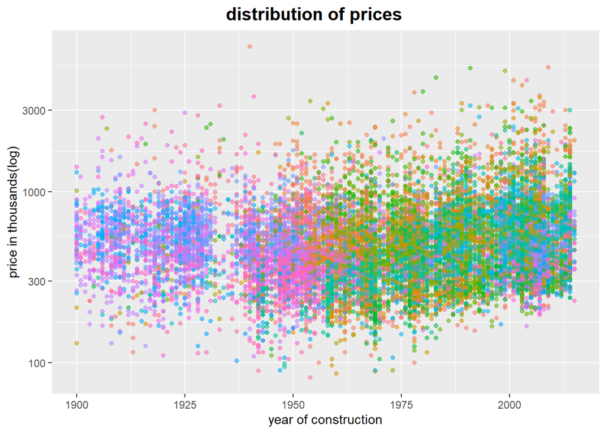

```r
# Tu umieść kod do wygenerowania odpowiedzi do zadania.
tmp <- df %>% group_by(zipcode) %>% summarise(count = n()) %>%
  filter(count > 280)

res <- df %>% filter(zipcode %in% tmp$zipcode) %>%
  mutate(zipcode = factor(zipcode))

ggplot(res, aes(x = yr_built, y = price/1000,
                color = zipcode, alpha = 0.5)) +
  geom_point() + theme(legend.position = "none") +
  scale_y_log10() +
  labs(title = "distribution of prices",
       y = "price in thousands(log)",
       x = "year of construction"
       ) +
  theme(plot.title = element_text(size = 15, face = "bold", hjust = 0.47))
```

**Komentarz:**

(kod pocztowy zaznaczony jest kolorem)

Nie ma wyrażnego wzrostu cen w zależności od roku budowy domu. Widoczne jest tworzenie nowych kodów pocztowych dla nowej nieruchomości.

## Zadanie 2

Czy jest różnica w rozkładzie ceny nierchomości od powierzchni mieszkalnej uwzględniając podział na nieruchomości z piwnicą i bez?

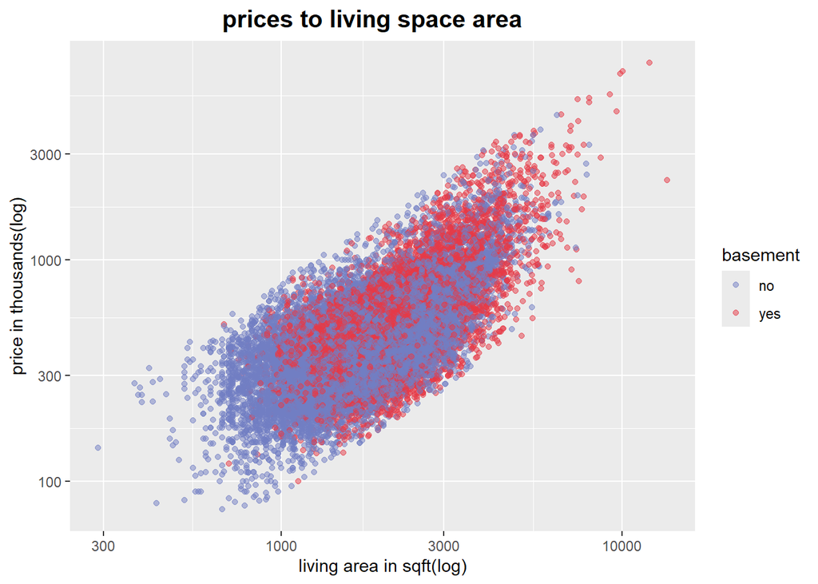

```r
# Tu umieść kod do wygenerowania odpowiedzi do zadania.
tmp <- df %>%
  mutate(has_basement = if_else(sqft_basement > 0,
                                "yes",
                                "no"))

ggplot(tmp, aes(x = sqft_living, y = price/1000,
                color = has_basement)) +
  geom_point(alpha = 0.5) +
  scale_color_manual(values = c("#717EC3", "#E63946")) +
  scale_y_log10() +
  scale_x_log10() +
  labs(title = "prices to living space area",
       y = "price in thousands(log)",
       x = "living area in sqft(log)",
       color = "basement"
       ) +
  theme(plot.title = element_text(size = 15, face = "bold", hjust = 0.47))
```

**Komentarz:**

Cena nieruchomości z piwnicą oraz bez rośnie wraz z powierzchnią.

## Zadanie 3

Jaka jest zależność pomiędzy jakością wykończenia nieruchomości a liczbą pięter?

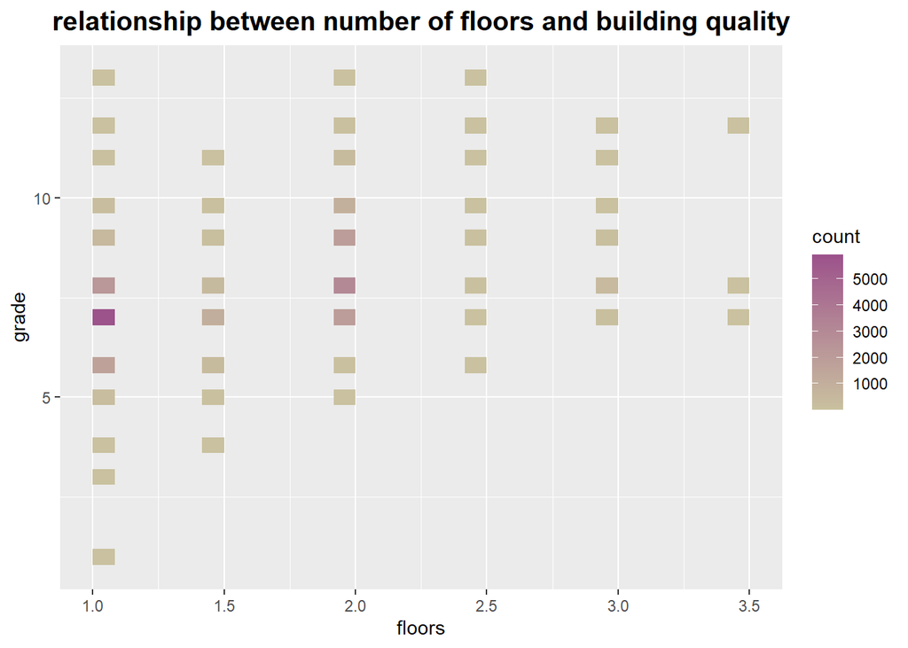

```r
# Tu umieść kod do wygenerowania odpowiedzi do zadania.
ggplot(df, aes(x = floors, y = grade)) +
  geom_bin2d() +
  labs(title = "relationship between number of floors and building quality",
       ) +
  theme(plot.title = element_text(size = 15, face = "bold", hjust = 0.47)) +
  scale_fill_gradient(low = "#C9C19F", high = "#9C528B")
```

**Komentarz:**

Jakość wykończenia nieruchomości rośnie z liczbą pięter, jednak najbardziej popularna kombinacja tych parametrów to jednopiętrowy budynek średniej jakości.

## Zadanie 4

Jaka jest zależność między powierzchnią mieszkalną nieruchomości a powierzchnią gruntu w podziale na liczbę sypialni?

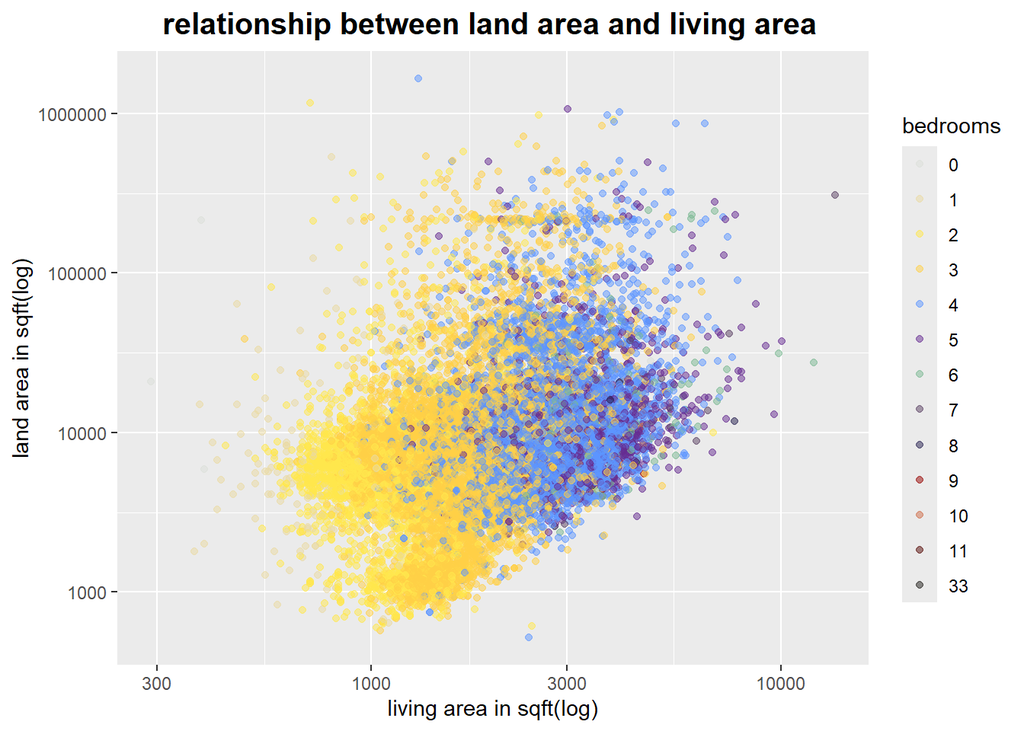

```r
# Tu umieść kod do wygenerowania odpowiedzi do zadania.
colors <- c("#241E4E", "#960200", "#CE6C47", "#FFD046",
            "#EADAA2", "#593F62", "#1E1B18", "#79B791",
            "#662C91", "#DCE0D9", "#540804", "#5C95FF",
            "#FFE74C")
colors <- colors[c(10, 5, 13, 4, 12, 9, 8, 6, 1, 2, 3, 11, 7)]

ggplot(df, aes(x = sqft_living, y = sqft_lot, color = factor(bedrooms))) +
  geom_point(alpha = 0.5) +
  labs(title = "relationship between land area and living area",
       y = "land area in sqft(log)",
       x = "living area in sqft(log)",
       color = "bedrooms"
       ) +
  scale_y_log10() + scale_x_log10() +
  scale_color_manual(values = colors) +
  theme(plot.title = element_text(size = 15, face = "bold", hjust = 0.47))
```

**Komentarz:**

Powierzchnia działki rośnie liniowo odnośnie powierzchni mieszkalnej. Liczba sypialni nie wpływa na relację. Większa liczba sypialni powiązana jest z większą powieżchnią mieszkalną.

## Zadanie 5

Rozważmy tylko nieruchomości, które miały remont. W której dekadzie było najwięcej przeprowadzonych remontów? Czy w poszczególnych dekadach jest porównywalny procent nieruchmości dla każdej wartości miary jakości i wykończenia nieruchomości?

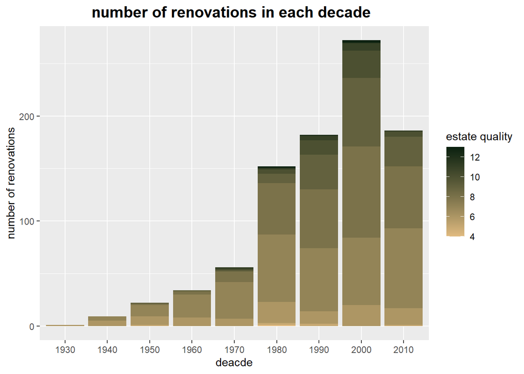

```r
# Tu umieść kod do wygenerowania odpowiedzi do zadania.
tmp <- df %>% filter(yr_renovated > 0) %>%
  mutate(decade = floor_date(ymd(paste0(yr_renovated,
                                        "-01-01")), "10 years")) %>%
  mutate(decade = year(decade))

tmp <- tmp %>% group_by(decade, grade) %>%
  summarise(count = n())

ggplot(tmp, aes(x = factor(decade), y = count, fill = grade)) +
  geom_col() +
  scale_fill_gradient(low = "#E1BB80", high = "#0A210F") +
  labs(title = "number of renovations in each decade",
       x = "deacde",
       y = "number of renovations",
       fill = "estate quality"
       ) +
  theme(plot.title = element_text(size = 15, face = "bold", hjust = 0.47))
```

**Komentarz:**

Najwięcej remontów przeprowadzono było w rokach 2000-2009. Większość remontów odbyła się w nieruchomości średniej jakości.

## Zadanie 6

Jak prezentuje się wartość minimalna, średnia i maksymalna ceny nieruchmości w podziele na rok budowy nieruchomości.

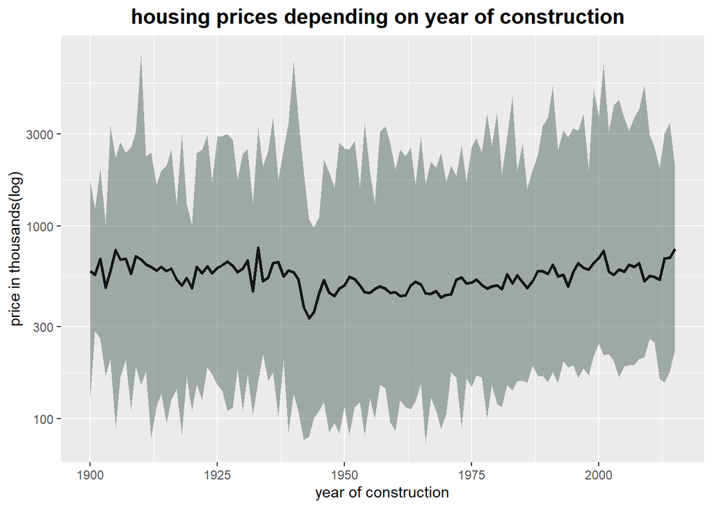

```r
# Tu umieść kod do wygenerowania odpowiedzi do zadania.
tmp <- df %>% group_by(yr_built) %>%
  summarize(min_price = min(price),
            max_price = max(price),
            mean_price = mean(price))

ggplot(tmp, aes(x = yr_built)) +
  geom_ribbon(aes(ymin = min_price/1000,
                  ymax = max_price/1000),
              fill = "#2D4739", alpha = 0.4) +
  geom_line(aes(y = mean_price/1000), color = "#121619", size = 1) +
  scale_y_log10()+
  labs(x = "year of construction",
       y = "price in thousands(log)",
       title = "housing prices depending on year of construction") +
  theme(plot.title = element_text(size = 15, face = "bold", hjust = 0.47))
```

**Komentarz:**